# coproID - Coprolite Identification

[figure not shown]

**Homepage/Documentation**: github.com/maxibor/coproID  
**Author:** Maxime Borry borry@shh.mpg.de

Report automatically generated by coproID version 0.6 on 2018-10-5 14:44:20

- **Organisms:**
  - *Bacillus subtilis* (genome size = 4215606 bp )
  - *Escherichia coli* (genome size = 4686137 bp)
- **The formula used to compute the read ratio is the following:**

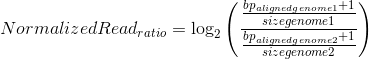

## coproID read ratio plot

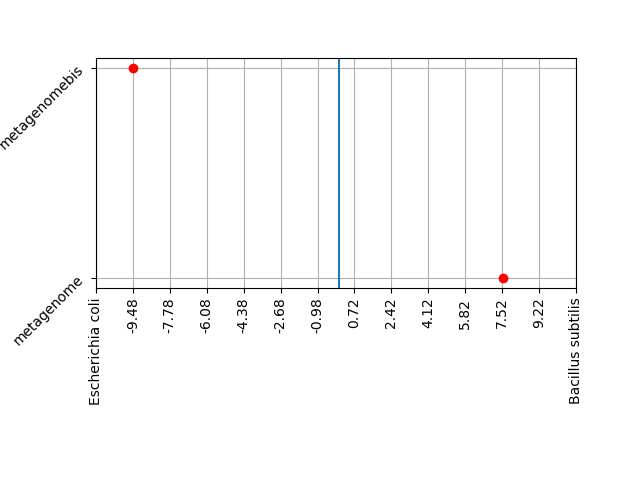

Normalized read ratio (*Bacillus subtilis*/*Escherichia coli*), blue line is an equal proportion of both genomes

### **Sample:** metagenome

- **Number of base pairs (bp) in reads aligned to *Bacillus subtilis* (genome 1) at 95.0% identity:** 1453421
- **Number of base pairs (bp) in reads aligned to *Escherichia coli* (genome 2) at 95.0% identity:** 8623

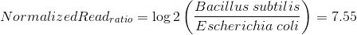

There are more *Bacillus subtilis* aDNA reads than *Escherichia coli* by > 2 folds. Therefore this coprolite is most likely originating from *Bacillus subtilis*

- **MapDamage plots**

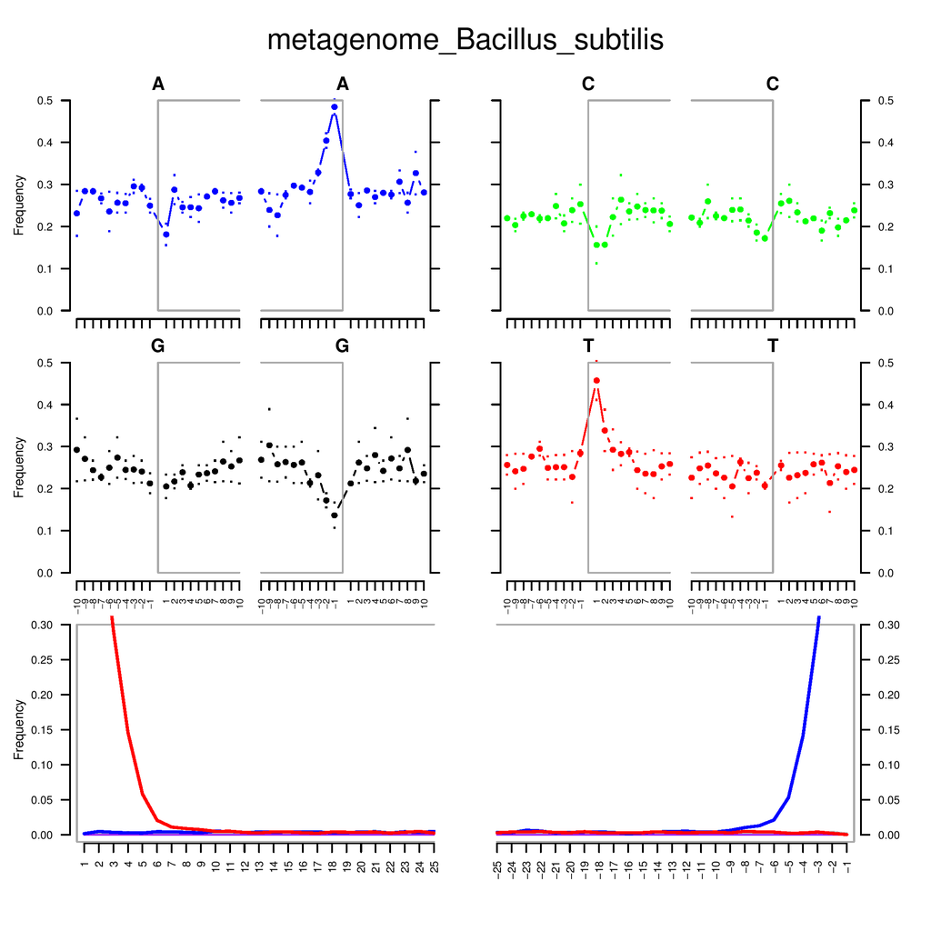

MapDamage Fragmisincorporation plot for Bacillus subtilis

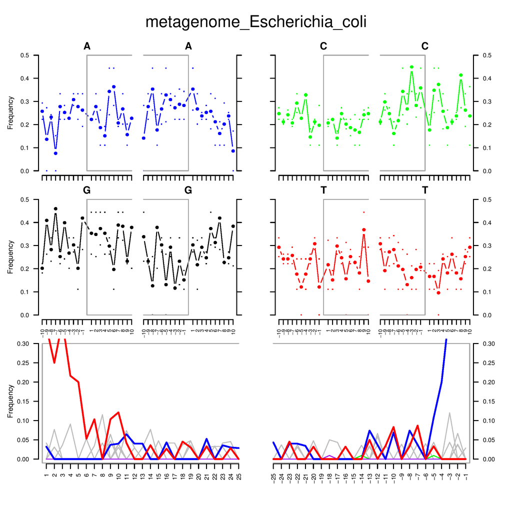

MapDamage Fragmisincorporation plot for Escherichia coli

### **Sample:** metagenomebis

- **Number of base pairs (bp) in reads aligned to *Bacillus subtilis* (genome 1) at 95.0% identity:** 4523
- **Number of base pairs (bp) in reads aligned to *Escherichia coli* (genome 2) at 95.0% identity:** 3597989

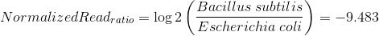

*There are more* Escherichia coli* aDNA reads than *Bacillus subtilis* by > 2 folds. Therefore this coprolite is most likely originating from *Escherichia coli*

- **MapDamage plots**

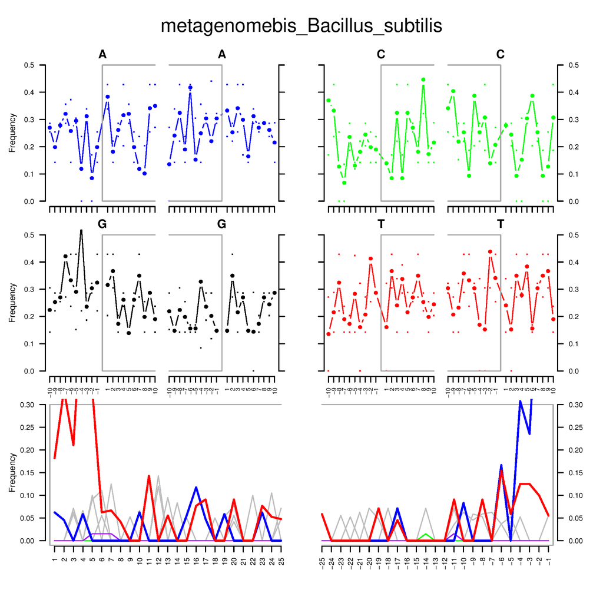

MapDamage Fragmisincorporation plot for Bacillus subtilis

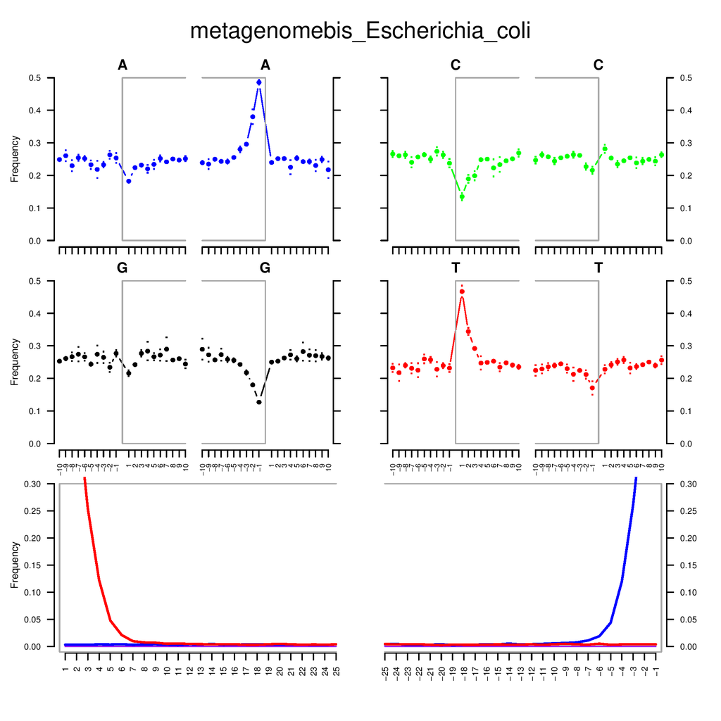

MapDamage Fragmisincorporation plot for Escherichia coli